# Course 5_Assignment1

birasafab

1/12/2021

##### Reading the required dataset for tidying and analysis

```r
library(readr)
Activity<-read_csv("activity.zip")

Activity$date<-as.Date(Activity$date,"%m/%d/%Y")
Weekday<-weekdays(Activity$date)
Activity<-cbind(Activity,Weekday)

summary(Activity)
```

```
##      steps             date               interval           Weekday
##  Min.   :  0.00   Min.   :2012-10-01   Min.   :   0.0   Friday   :2592
##  1st Qu.:  0.00   1st Qu.:2012-10-16   1st Qu.: 588.8   Monday   :2592
##  Median :  0.00   Median :2012-10-31   Median :1177.5   Saturday :2304
##  Mean   : 37.38   Mean   :2012-10-31   Mean   :1177.5   Sunday   :2304
##  3rd Qu.: 12.00   3rd Qu.:2012-11-15   3rd Qu.:1766.2   Thursday :2592
##  Max.   :806.00   Max.   :2012-11-30   Max.   :2355.0   Tuesday  :2592
##  NA's   :2304                                           Wednesday:2592
```

# Mean Total

#### Ploting the total number of steps taken per day

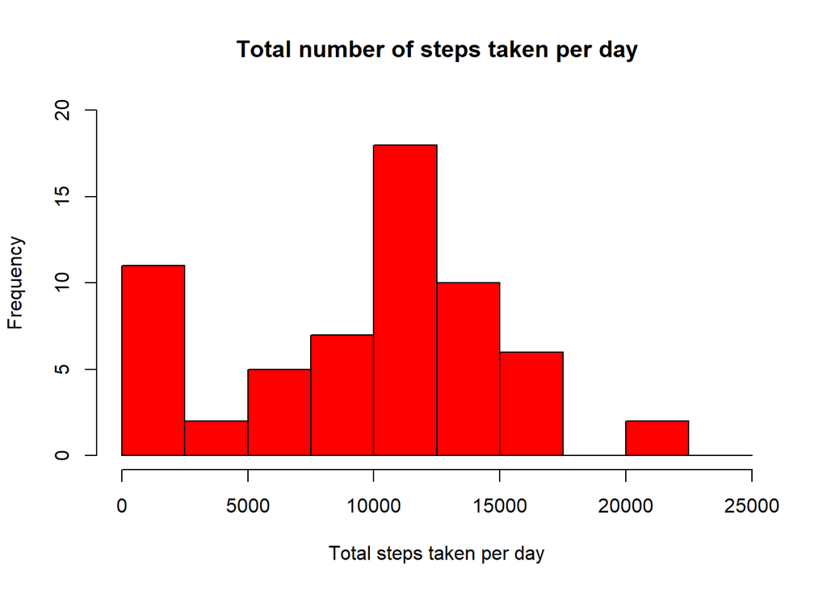

```r
Total_steps_Day<-with(Activity, aggregate(steps,by = list(date),FUN = sum, na.rm = TRUE),sort=TRUE)
names(Total_steps_Day)<-c("date","steps")

# ploting the histogram of the total number of steps taken per each day
hist(Total_steps_Day$steps,main = "Total number of steps taken per day", col = "red", xlab = "Total steps taken per day",ylim = c(0,20), breaks = seq(0,25000, by = 2500))
```

#### Mean of total number of steps taken per day

```r
mean(Total_steps_Day$steps)
```

```
## [1] 9354.23
```

#### Median of total number of steps taken per day

```r
median(Total_steps_Day$steps)
```

```
## [1] 10395
```

# Average daily pattern

#### What is the average daily activity pattern?

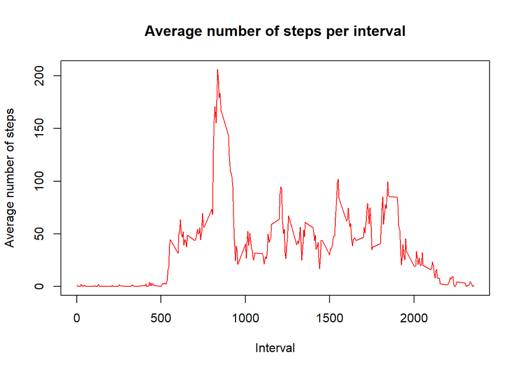

```r
average_daily_activity <- aggregate(Activity$steps, by = list (Activity$interval), FUN = mean, na.rm = TRUE)

names(average_daily_activity)<-c("interval","mean")

plot(average_daily_activity$interval,col = "red", average_daily_activity$mean,type = "l", xlab = "Interval", ylab = "Average number of steps", main = "Average number of steps per interval")
```

## 5-minute interval, max

##### Finding which 5-minute interval contains the maximum number of steps, on average across all the days in the dataset

```r
average_daily_activity[which.max(average_daily_activity$mean),]$interval
```

```
## [1] 835
```

# Imputing Missing Values

### Calculating the total number missing values in the entire dataset

```r
max(row(Activity))-sum(complete.cases(Activity))
```

```
## [1] 2304
```

### Devise a strategy for filling in all the missing values in the dataset

```r
steps_clean<- average_daily_activity$mean[match(Activity$interval,average_daily_activity$interval)]
```

### Creating a new dataset that is equal to the original dataset but with the missing data filled in:

```r
Activity_clean <- transform(Activity, steps =  ifelse(is.na(Activity$steps),steps_clean,Activity$steps))

Total_clean_steps <- aggregate(steps ~ date, Activity_clean,sum)

names(Total_clean_steps) <- c("date","daily_steps")
```

### Make a histogram of the total number of steps taken each day and calculate and report the mean and median total number of steps taken per day. Verify if these values differ from the estimates from the first part of the assignment. and What is the impact of imputing missing data on the estimates of the total daily number of steps?

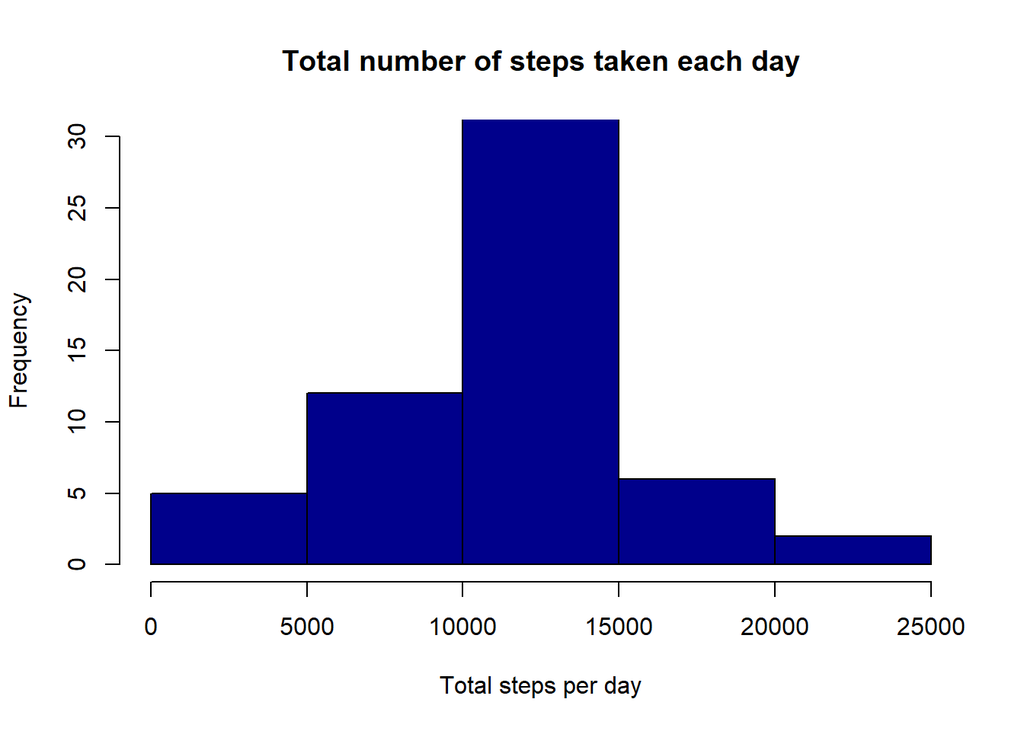

```r
hist(Total_clean_steps$daily_steps, col = "darkblue",xlab = "Total steps per day", ylim = c(0,30), main = "Total number of steps taken each day")
```

### Calculating the Mean of the total number of steps taken per day

```r
mean(Total_clean_steps$daily_steps)
```

```
## [1] 10766.19
```

### Calculating the Median of the total number of steps taken per day

```r
median(Total_clean_steps$daily_steps)
```

```
## [1] 10766.19
```

## Are there differences in activity patterns between weekdays and weekends?

```r
tail(Activity)
```

```
##       steps       date interval Weekday
## 17563    NA 2012-11-30     2330  Friday
## 17564    NA 2012-11-30     2335  Friday
## 17565    NA 2012-11-30     2340  Friday
## 17566    NA 2012-11-30     2345  Friday
## 17567    NA 2012-11-30     2350  Friday
## 17568    NA 2012-11-30     2355  Friday
```

```r
Activity$datetype = sapply (Activity$date, function(x)
        {
                if (weekdays(x) == "Saturday" | weekdays(x) == "Sunday")
                {y <- "Weekend"} else
                {y <- "Weekday"}
                y
        })
```

### A panel plot containing a time series plot (type = “l”) of the 5-minute interval (x-axis) and the average number of steps taken, averaged across all weekday days or weeekend days (y-axis)

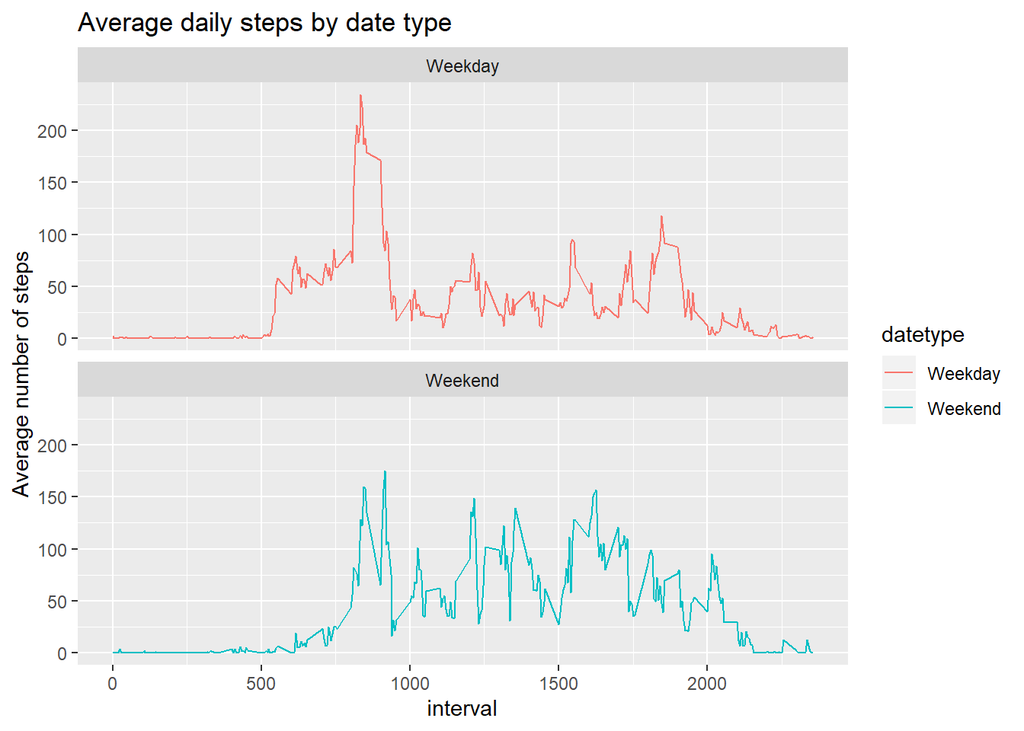

```r
Activity.datetype<-aggregate(steps~interval+datetype,Activity,mean, na.rm = TRUE)

library(ggplot2)
ggplot(Activity.datetype, aes(x = interval, y = steps, color = datetype)) + geom_line() + labs(title = "Average daily steps by date type", X = "Interval", y = "Average number of steps") + facet_wrap(~datetype, ncol = 1, nrow=2)
```

#End.